# Regression

## Correlation doesn’t imply Causation

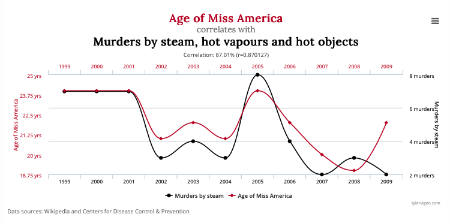

But it may, if there is a good independent reason to think that X influences Y.

## Regression implies X causes Y

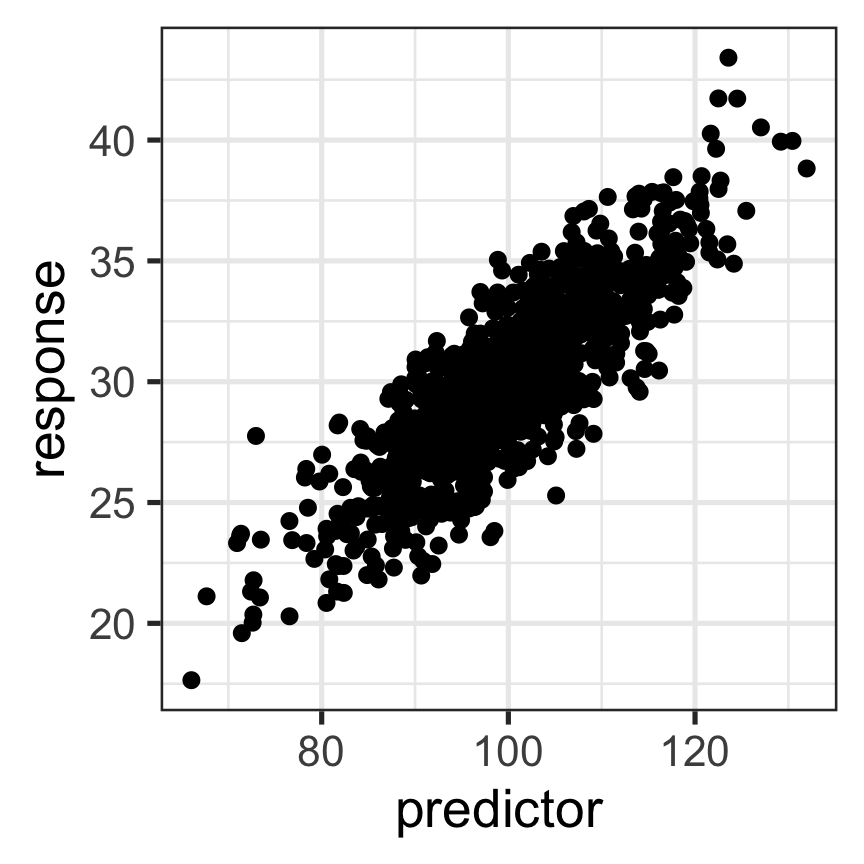

\[Y = slope \times X + intercept\]

- Both variables are continuous
- TONS of data are suitable for this kind of analysis.
- Examples?

## Simple Linear Model

Simplest way two variables can be modeled as related to one another

\[Y_i = \beta_0 + \beta_1X_i + \epsilon_i\]

- \(\beta_0\) is the **intercept** (value of y where x= 0)
- \(\beta_1\) is the **slope** value expressing \(\Delta Y / \Delta X\)
- \(\epsilon_i\) is the error term (a normal random variable with mean 0 and variance \(\sigma^2\))

## This equation should make sense

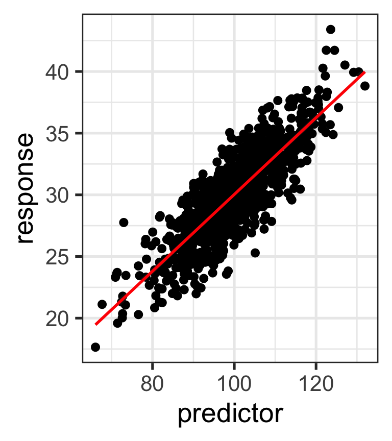

\[Y_i = \beta_0 + \beta_1X_i + \epsilon_i\]

Once you decide on a line, then the value of Y equals:

- the value predicted by the line, plus
- a random error from our error term

## Finding the best line

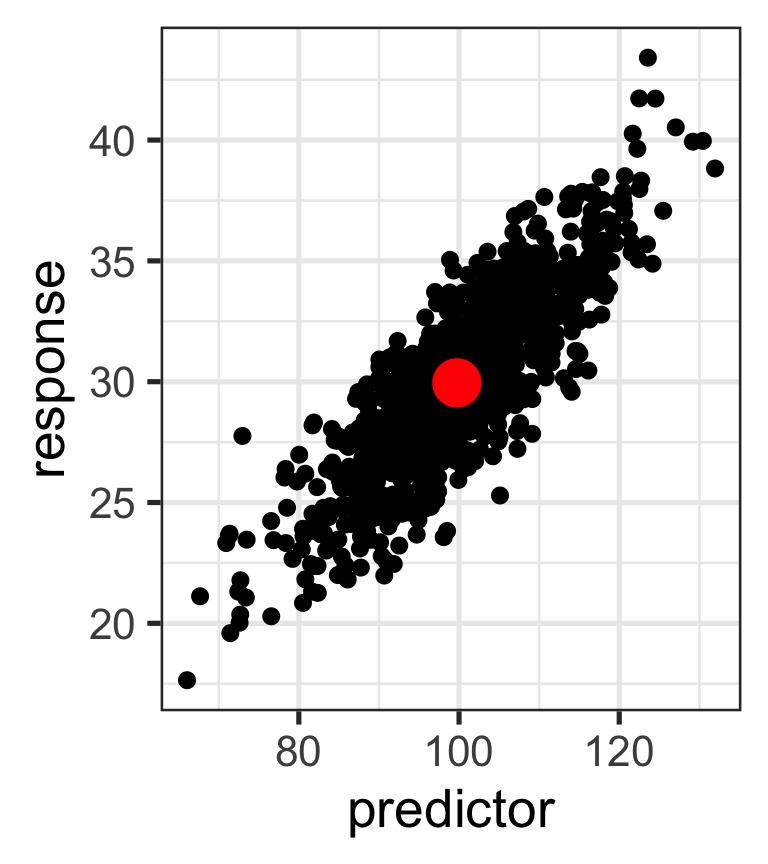

- Many lines pass through \((\bar{X},\bar{Y})\). How do we pick the best one?
- There is unexplained variation in Y, so points don’t fall on straight line (why?)

## Finding the best line - residuals

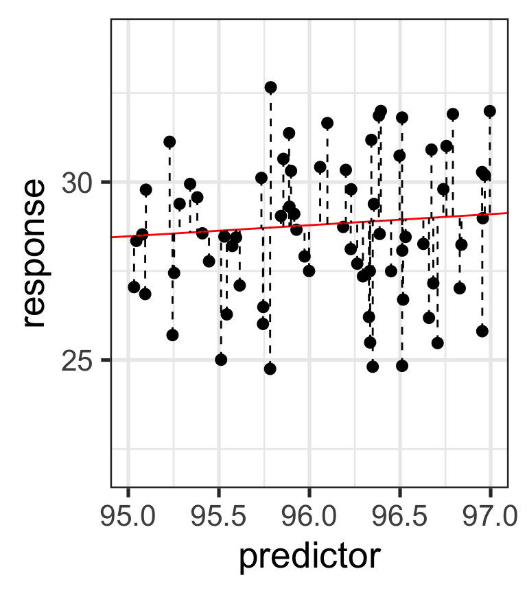

A **residual** represents the distance between the predicted value from the regression, and the actual value.

Another way to think about the residual: a single value from the normally distributed error term.

The **squared residual** is calculated as such:

\[d_i^2=(Y_i - \hat{Y}_i)^2\]

## Finding the best line

The best line minimizes the **residual sum of squares**

\[ RSS=\sum\limits_{i=1}^n(Y_i - \hat{Y}_i)^2\]

We could do a Monte Carlo approach: try a bunch of slopes passing through \((\bar{X},\bar{Y})\) and calculate the RSS, then pick the smallest, but math offers a simpler solution.

## Variances and Covariances

Recall the **sum of squares**: \[\ SS_Y = \sum\limits_{i=1}^n(Y_i - \bar{Y})^2\]

**Sample variance**: \[\ s^2_Y=\frac{\sum\limits_{i=1}^n(Y_i - \bar{Y})^2}{n-1}\]

SS equivalent to: \[\ SS_Y = \sum\limits_{i=1}^n(Y_i - \bar{Y})(Y_i - \bar{Y})\]

## Variances and Covariances

With 2 variables, we can define **sum of cross products** \[\ SS_{XY} = \sum\limits_{i=1}^n(X_i - \bar{X})(Y_i - \bar{Y})\]

By analogy to the sample variance, we define **sample covariance** \[\ s_{XY} = \frac{\sum\limits_{i=1}^n(X_i - \bar{X})(Y_i - \bar{Y})}{(n-1)}\]

## Sample Covariance - Negative

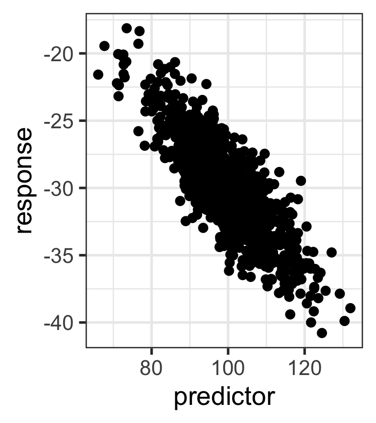

From \(-\infty\) to \(\infty\)

\[\ s_{XY} = \frac{\sum\limits_{i=1}^n(X_i - \bar{X})(Y_i - \bar{Y})}{(n-1)}\]

## Sample Covariance - Positive

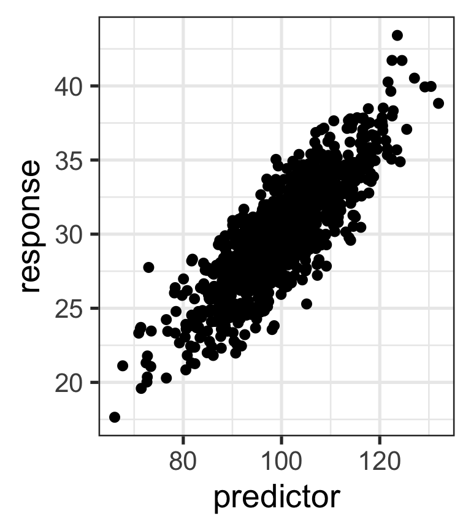

From \(-\infty\) to \(\infty\)

\[\ s_{XY} = \frac{\sum\limits_{i=1}^n(X_i - \bar{X})(Y_i - \bar{Y})}{(n-1)}\]

## Calculate Covariance

By hand on whiteboard

```r
x <- c(2 , 4, 3)
y <- c(1, 5, 6)
```

## Regression Parameters - Slope

In **ordinary least squares regression (OLS)**, the slope of the best fit line is defined as: \[ \frac{covariance\ of\ XY}{variance\ of\ X}\]

Or: \[\hat{\beta}_1 = \frac{s_{XY}}{s^2_X} = \frac{SS_{XY}}{SS_X}\] **note: this simplifies because both are divided by same denomenator**

## Regression Parameters - Intercept

The intercept is easy to find, because the best fit line passes through \((\bar{X},\bar{Y})\). Thus: \[ \bar{Y} = \hat{\beta}_0 + \hat{\beta}_1 \bar{X} \]

Or:

\[ \hat{\beta}_0 = \bar{Y} - \hat{\beta}_1 \bar{X}\]

## Regression Parameters - Error

Recall: \[Y_i = \beta_0 + \beta_1X_i + \epsilon_i\]

Regression assumes that that \(\epsilon\) is a random normal variable with mean 0 and variance of \(\sigma^2\), which is related to the scatter around the line.

We estimate \(\sigma^2\) like this: \[\frac{RSS}{n-2}\]

The square root of this is **standard error of regression**: \[\hat{\sigma}^2=\sqrt{\frac{RSS}{n-2}}\]

## Coefficient of Determination

In a linear relationship, the total variance we want to explain is \(SS_Y\).

Some variance is attributable to our error term (measured by \(RSS\)).

The remaining variance is explained by our regression, thus: \[SS_{reg}=SS_Y-RSS\]

Therefore: \[SS_Y=SS_{reg}+RSS\]

This is referred to as **partitioning** a sum of squares.

## Coefficient of Determination

This leads to calculation of \(r^2\), AKA the **coefficient of determination**

\[r^2 = \frac{SS_{reg}}{SS_Y}=\frac{SS_{reg}}{SS_{reg} + RSS}\]

The square root of this value is known as \(r\) or the **product-moment correlation coefficient**.

Note: the sign of \(r\) comes from the sign of the slope of the line.

## Hypothesis Testing

You will always get parameter estimates for the intercept and slope. The next question is: **are they signficant?**

The slope measures the strength of the effect of \(X\) on \(Y\). The slope is a measure of **effect size**

## What is the null hypothesis about the slope in regression?

## Hypothesis Testing ANOVA tables

| Source | Degrees of Freedom (df) | Sum of squares (SS) | Mean Square (MS) | F-ratio | P-value |  |
| --- | --- | --- | --- | --- | --- | --- |
| Regression | 1 | \(SS_{reg}=\sum\limits_{i=1}^n (\hat{Y}_i-\bar{Y})^2\) | \(\frac{SS_{reg}}{1}\) | \(\frac{SS_{reg}/1}{RSS/(n-2)}\) | F dist |  |
| Residual | n-2 | \(RSS=\sum\limits_{i-1}^n(Y_i - \hat{Y}_i)^2\) | \(\frac{RSS}{(n-2)}\) |  |  |  |

- \(\bar{Y}\) = mean of Y
- \(\hat{Y}_i\) = predicted value from regression
- \(Y_i\) = value of Y

## Confidence Intervals

We can also construct confidence intervals around our parameter estimates (formulae not shown).

Notice that our intervals are narrowest near the mean, and fatter the further you go away from mean.

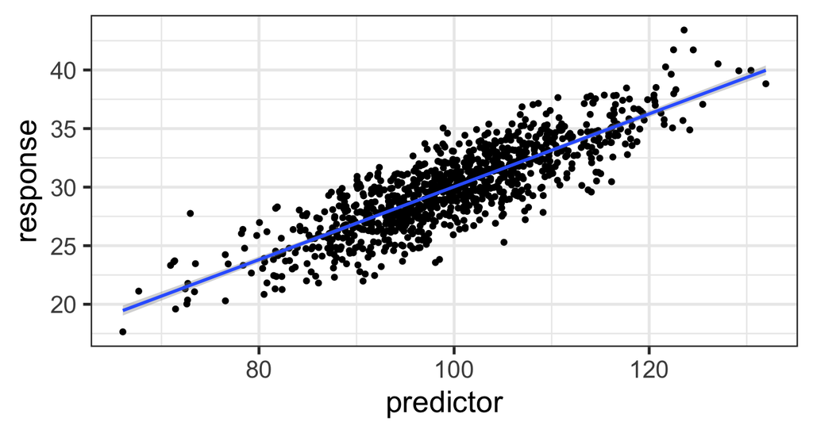

## Interpolation vs Extrapolation

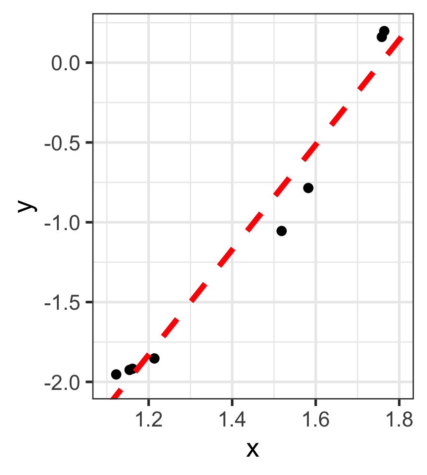

## Interpolation vs Extrapolation

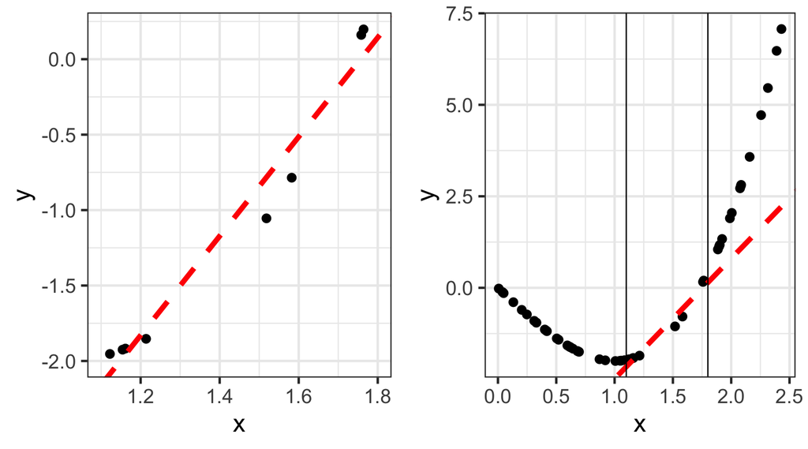

## Assumptions of Regression

- The causal relationship between X and Y is linear.
- The X variable is measured without error.
  - Datasets that don’t meet this require Model II (a.k.a., RMA)
- Y values are independent with normally distributed errors
- Variance is constant along the regression line (homoscedasticity)

## Doing Regression in R

```r
myModel <- lm(response~predictor)
summary(myModel)
```

```
##
## Call:
## lm(formula = response ~ predictor)
##
## Residuals:
##    Min     1Q Median     3Q    Max
## -6.332 -1.288  0.029  1.307  6.137
##
## Coefficients:
##              Estimate Std. Error t value Pr(>|t|)
## (Intercept) -1.082286   0.623277  -1.736   0.0828 .
## predictor    0.311143   0.006218  50.036   <2e-16 ***
## ---
## Signif. codes:  0 '***' 0.001 '**' 0.01 '*' 0.05 '.' 0.1 ' ' 1
##
## Residual standard error: 1.96 on 998 degrees of freedom
## Multiple R-squared:  0.715,  Adjusted R-squared:  0.7147
## F-statistic:  2504 on 1 and 998 DF,  p-value: < 2.2e-16
```

## Checking Assumptions: Residual plot

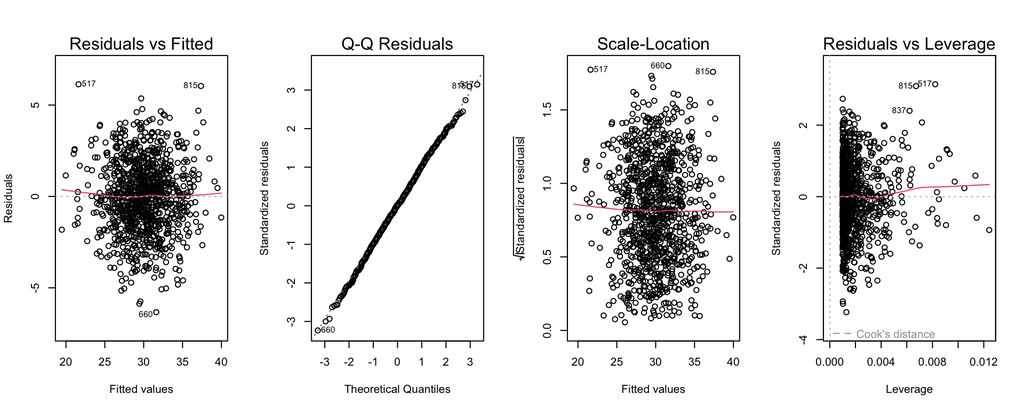

```r
plot(lm(response~predictor))
```

Any systematic correlation between the residuals and the fitted is bad.

## Checking Assumptions: Residual plot

Systematic departures from linearity can show up in the residual plots

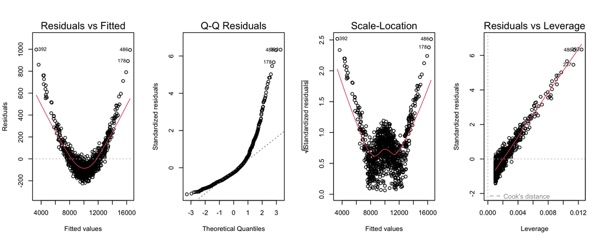

```r
response <- predictor^2 + rnorm(1000, sd=50)
plot(lm(response~predictor))
```

## Model II Regression - A different kind of residual

RMA regression assumes there is error in both X and Y and minimizes an orthogonal residual sum of squares (along the major axis). Below, red line is Model II line (residuals are 90 degrees to this line.) Blue line shows the standard regression with vertical residuals.

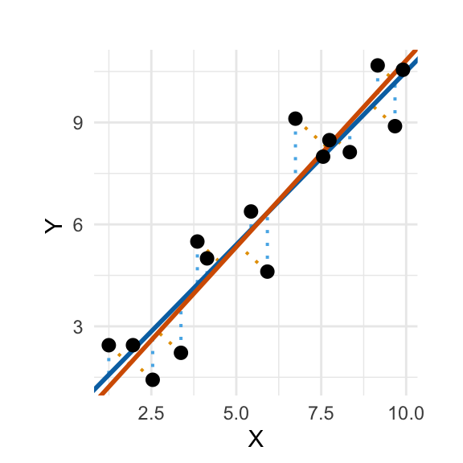

## Doing Model II Regression in R

Model II regression requires a separate package `lmodel2`

In bioanthro literature, this regression is known as RMA (reduced major axis), but known in this package as MA (RMA in this package is something else)

The function is different, but the call is still simple.

## Doing Model II Regression in R

```r
library(lmodel2)
results <- lmodel2(response~predictor)
print(results)
```

```
##
## Model II regression
##
## Call: lmodel2(formula = response ~ predictor)
##
## n = 1000   r = 0.8318485   r-square = 0.691972
## Parametric P-values:   2-tailed = 1.943335e-257    1-tailed = 9.716673e-258
## Angle between the two OLS regression lines = 6.614198 degrees
##
## Regression results
##   Method  Intercept     Slope Angle (degrees) P-perm (1-tailed)
## 1    OLS  0.8163301 0.2927504        16.31741                NA
## 2     MA -0.2438352 0.3033804        16.87677                NA
## 3    SMA -5.0856439 0.3519276        19.38838                NA
##
## Confidence intervals
##   Method 2.5%-Intercept 97.5%-Intercept 2.5%-Slope 97.5%-Slope
## 1    OLS     -0.3997441        2.032404  0.2806177   0.3048831
## 2     MA     -1.5022970        1.005865  0.2908500   0.3159985
## 3    SMA     -6.3165411       -3.896451  0.3400039   0.3642694
##
## Eigenvalues: 108.3025 3.485197
##
## H statistic used for computing C.I. of MA: 0.0001325621
```

## In Class Breakout Group Exercise

20 minutes

## Gordon et al. 2008

[figure not shown]

## Gordon et al. 2008

We are going to look at the scaling relationship between overall size and BBH (basion-bregma-height) in humans and fossil hominins

[figure not shown]

## Exercise Step 1 - Import data

- `heads` - [Howell Craniometric Data](https://stats.are-awesome.com/datasets/Howell_craniometry.txt)
- `fossils` - [Fossil Data](https://stats.are-awesome.com/datasets/Gordon_2008_cranial.txt)

## Exercise Step 2 - Calculate Geomean

Calculate the geomean for each individual in both data sets using the variables GOL, BBH, XCB, BNL, BPL, ASB

Add this data to a new column called `geomean`

```r
geomean <- function(x, na.rm = TRUE) {
  product <- prod(x, na.rm = TRUE)
  n <- sum(!is.na(x))
  geo <- product ^ (1/n)
  return(geo)
  }
```

## Exercise Step 3 - Do Regression

Do an Ordinary Least Squares regression of `log(BBH)` as a function of `log(geomean)` for the modern data and a separate one for the fossils

## Exercise Step 4 - Make Plots

Make a plot of `log(BBH)` as a function of `log(geomean)`

- plot the modern humans
  - and add the modern human regression line to the plot
- add a new layer with the fossil data, being sure to differentiate them visually
  - add the fossil regression line to the plot, using a different kind of line (e.g. dashed, or a different color)

## Exercise Step 5 - Interpret

How do the fossils compare to the modern humans?

How does LB1 (*H. floresiensis*) compare to other species?